**Dragos Ailoae**

Applied Statistics and Econometrics I

2021-10-03

# Homework 1 - Suggested Solutions

### Problem 1:

Show that $E(Y)=\left(\theta_{1}+\theta_{2}\right) / 2$ when $Y$ is a uniformly distributed random variable on the interval $\left(\theta_{1}, \theta_{2}\right) .$

Per [Greene Appendix](http://pages.stern.nyu.edu/~wgreene/Text/Greene-EA-7&8ed-Appendices.pdf):

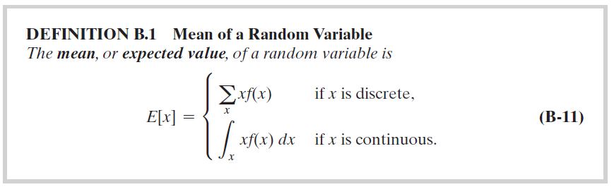

For a [uniformly distributed](https://en.wikipedia.org/wiki/Continuous_uniform_distribution) random variable the probability density function (PDF) is:

$$ f(x)=\left\{\begin{array}{l} \frac{1}{\theta_{2}-\theta_{1}}, \quad \text { if } \quad \theta_{1} \leq x \leq \theta_{2} \\ 0, \quad \text { otherwise } \end{array}\right. $$

Therefore:

$$ \begin{aligned} E[Y]&=\int_{\theta_{1}}^{\theta_{2}} Y f(Y) d Y =\int_{\theta_{1}}^{\theta_{2}} Y \frac{1}{\theta_{2}-\theta_{1}} d Y =\frac{1}{\theta_{2}-\theta_{1}} \int_{\theta_{1}}^{\theta_{2}} Y d Y \\ &=\left.\frac{1}{\theta_{2}-\theta_{1}} \frac{Y^{2}}{2}\right|_{\theta_{1}} ^{\theta_{2}} =\frac{1}{\theta_{2}-\theta_{1}} \frac{\theta_{2}^{2}-\theta_{1}^{2}}{2} =\frac{\left(\theta_{2}-\theta_{1}\right)\left(\theta_{2}+\theta_{1}\right)}{2\left(\theta_{2}-\theta_{1}\right)} =\frac{\theta_{2}+\theta_{1}}{2} \\ & QED \end{aligned} $$

### Problem 2:

Consider an experiment that consists of tossing a die and flipping a coin at the same time. Consider the following random variables:

$X_1$: The number of dots appearing on the die.

$X_2$: The sum of the number of dots on the die and the indicator for the coin, where the value of a head is 1 and the value of a tail is zero.

a) How many possible events are there, and what are they? What are the possible outcomes and associated probabilities for $X_2$ ?

We can create a tree diagram for this experiment

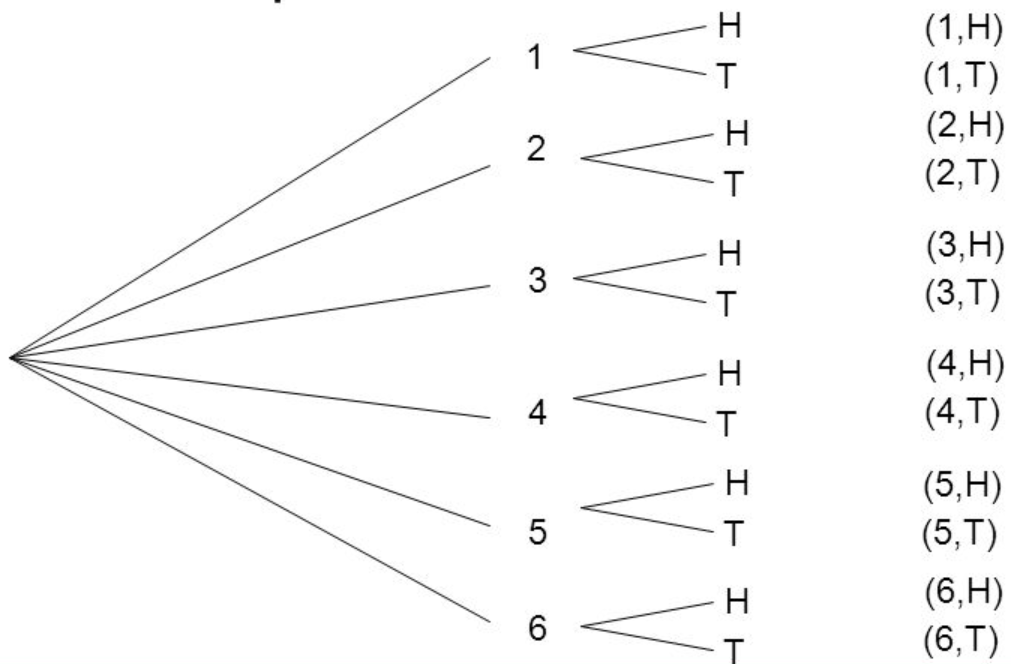

Then, letting Head = 1 and Tail = 0, we can rewrite the possible event space E as: $$ \left(\begin{array}{c} (1,0),(2,0),(3,0),(4,0),(5,0),(6,0) \\ (1,1),(2,1),(3,1),(4,1),(5,1),(6,1) \end{array}\right) $$

for a total of 12 possible events.

The corresponding values for $X_2$ are then: $$ \left(\begin{array}{c} (1),(2),(3),(4),(5),(6) \\ (2),(3),(4),(5),(6),(7) \end{array}\right) $$

Tabulating, the possible outcomes and associated probabilities for $X_2$ are:

| Value | Probability |  |
| --- | --- | --- |
| 1 | 1/12 |  |
| 2 | 1/6 |  |
| 3 | 1/6 |  |
| 4 | 1/6 |  |
| 5 | 1/6 |  |
| 6 | 1/6 |  |
| 7 | 1/12 |  |

Alternately, define random variable $C \equiv$ coin toss outcome. Then,

$$ \begin{aligned} P\left(X_{2}=1\right)&=P\left(X_{1}=1\right) \times P(C=0)=\frac{1}{6} \cdot \frac{1}{2}=\frac{1}{12} \\ P\left(X_{2}=2\right)&=P\left(X_{1}=1\right) \times P(C=1)+P\left(X_{1}=2\right) \times P(C=0)=\frac{1}{12}+\frac{1}{12}=\frac{1}{6} \\ P\left(X_{2}=3\right)&=P\left(X_{1}=2\right) \times P(C=1)+P\left(X_{1}=3\right) \times P(C=0)=\frac{1}{12}+\frac{1}{12}=\frac{1}{6} \\ \vdots \\ P\left(X_{2}=7\right)&=P\left(X_{1}=6\right) \times P(C=1)=\frac{1}{12} \end{aligned} $$

b) What is the $P(X_1=3, X_2=3)$ ?

First note that $P(X_1=3, X_2=3) \neq P(X_1=3)\times P(X_2=3)$. This is because $X_2$ is a function of $X_1$ which means the two random variables **ARE NOT** independent. Per [Greene Appendix](http://pages.stern.nyu.edu/~wgreene/Text/Greene-EA-7&8ed-Appendices.pdf):

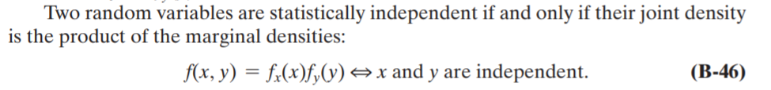

Also from Greene:

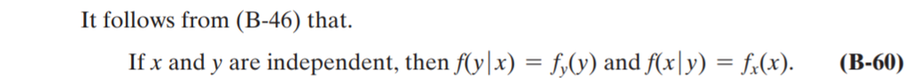

In our case $P(X_2)$ is dependent on $X_1$ i.e. $P(X_2 | X_1)\neq P(X_2)$.

However, we know that the bivariate conditional density is defined as (see [Greene Appendix](http://pages.stern.nyu.edu/~wgreene/Text/Greene-EA-7&8ed-Appendices.pdf) or [here](https://en.wikipedia.org/wiki/Conditional_probability)):

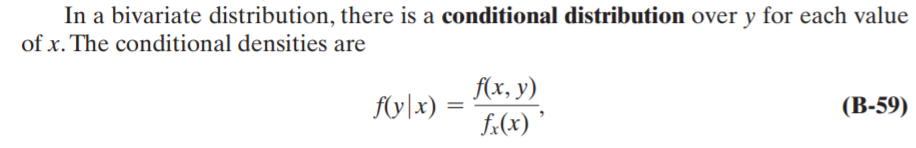

In our case then, $$ P(X_2 = 3 | X_1=3) = \frac {P(X_1 = 3, X_2=3)}{P(X_1=3)} $$

Or, rearranging,

$$ P(X_1 = 3 , X_2=3) = P(X_1=3) \times P(X_2 = 3 | X_1=3) $$

But $P(X_2 = 3 | X_1=3)=\frac{1}{2}$, i.e. the probability of the coin flip being 0. Thus we have: $$ \begin{aligned} P(X_1 = 3 , X_2=3) &= P(X_1=3) \times P(X_2 = 3 | X_1=3) \\ &= \frac{1}{6} \times \frac{1}{2} \\ &=\frac{1}{12} \end{aligned} $$

The complete bivariate distribution $f(X_1,X_2)$ is:

[figure not shown]

### Problem 3:

A local supermarket has three checkout counters. Two customers arrive at the counters at different times when the counters are serving no other customers. Each customer chooses a counter at random, independently of the other. Let $Y_1$ denote the number of customers who select counter 1 and $Y_2$, the number who select counter 2. Find the joint distribution of $Y_1$ and $Y_2$.

The key is to note that the two customers choose "independently of the other". This means we can have 2 customers select the same counter and so we can have 0, 1, or 2 customers at a given counter.

Let's first look at the sample space in terms of the counter selected by each of the two customers. Let the pair {i, j} denote the simple event that the first customer chooses counter i and the second customer chooses counter j, with i = {1,2,3} and j = {1,2,3}. The sample space then consists of 9 possible checkout counter pairs:

$$ S(i,j) = \{(1,1), (1,2), (1,3), (2,1), (2,2), (2,3), (3,1), (3,2), (3,3)\} $$

Now, in terms of the RVs defined in the problem

$Y_1$ = number of customers who select counter 1

$Y_2$ = number of customers who select counter 2

Therefore $S(i,j) = (1,1)$ is equivalent to $(Y_1 = 2, Y_2 = 0)$ and so $P(Y_1 = 2, Y_2 = 0)=\frac{1}{9}$

Similarly, the event $(Y_1 = 1, Y_2 = 1)$ is equivalent to $S(i,j) =\{(2,1),(1,2)\}$ therefore $P(Y_1 = 1, Y_2 = 1)=\frac{1}{9} +\frac{1}{9} = \frac{2}{9} $

The complete bivariate distribution $f(Y_1,Y_2)$ is:

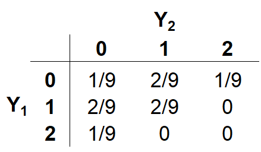

### Problem 4:

Is the estimator $Z$ shown below a biased and/or consistent estimator of the population mean, $\mu$?

$$ Z=\frac{1}{n+1} \sum_{i=1}^{n} X_{i} $$

Per [Greene Appendix](http://pages.stern.nyu.edu/~wgreene/Text/Greene-EA-7&8ed-Appendices.pdf):

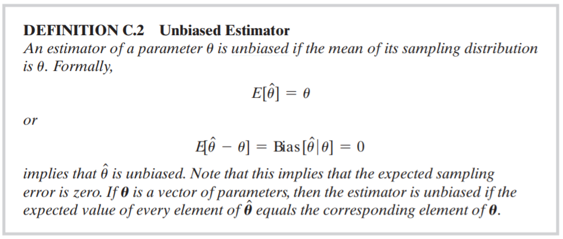

We are given the true population mean $E[X]=\mu$. To prove that the estimator Z is unbiased we need to prove that $E[Z]=E[X]=\mu$.

The expected value of $Z$ is then $$ E[Z]=E\left[ \frac{1}{n+1} \sum_{i=1}^{n} X_{i} \right] $$

Since $\frac{1}{n+1}$ is a constant (i.e. not a random variable) we can pull it out of the expectation operator, thus: $$ E[Z]=E\left[ \frac{1}{n+1} \sum_{i=1}^{n} X_{i} \right] = \frac{1}{n+1} \sum_{i=1}^{n} E[X_{i}] = \frac{1}{n+1} n E[X] = \frac{n}{n+1} \mu $$

Since $E[Z] \neq \mu$, estimator Z is **biased.** (Note $E[Z] < \mu$ so negatively biased)

As far as consistency, per [Greene Appendix](http://pages.stern.nyu.edu/~wgreene/Text/Greene-EA-7&8ed-Appendices.pdf):

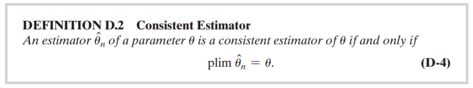

We can see that, asymptotically

$$ \lim _{n \rightarrow \infty} E\left[ Z \right]=\lim _{n \rightarrow \infty} \frac{n}{n+1} \mu = \mu $$

Also,

$$ \begin{aligned} var[Z]&=E\left[(Z - E[Z])^2 \right] \\ &=E\left[ \left( \left( \frac{1}{n+1} \sum_{i=1}^{n} X_{i} \right) - \left(\frac{n}{n+1} \mu \right) \right)^2 \right]\\ &=E\left[ \frac{1}{(n+1)^2} \left( \left( \sum_{i=1}^{n} X_{i} \right) - n \mu \right)^2 \right]\\ &=\frac{1}{(n+1)^2} E\left[ \left( \left( \sum_{i=1}^{n} X_{i} \right) - n \mu \right)^2 \right]\\ &=\frac{1}{(n+1)^2} E\left[ \left( \sum_{i=1}^{n} X_{i} - \mu \right)^2 \right]\\ &=\frac{1}{(n+1)^2} n E\left[ \left( X - \mu \right)^2 \right]\\ \end{aligned} $$

Note that $E\left[ \left( X - \mu \right)^2 \right] = var[X] \equiv \sigma_X^2$ so that

$$ \begin{aligned} var[Z]&=\frac{1}{(n+1)^2} n E\left[ \left( X - \mu \right)^2 \right]\\ &= \frac{n}{(n+1)^2} \sigma_X^2 \end{aligned} $$

We can see then that,

$$ \lim _{n \rightarrow \infty} var\left[ Z \right]=\lim _{n \rightarrow \infty} \frac{n}{(n+1)^2} \sigma_X^2 = 0 $$

Therefore $$ \text{plim Z} = \mu $$

This means that as n grows the distributions of the Z estimates become more and more concentrated near the true value, so that the probability of the estimator being arbitrarily close to $\mu$ converges to 1. Estimator Z is therefore **consistent**.

### Problem 5:

Download the R package AER. This package contains a number of data sets. Upload the data set “USInvest” into a data frame as a time series. You will find the data set listed under Greene (2003).

According to the documentation for the AER package available [here](https://cran.r-project.org/web/packages/AER/AER.pdf) the 'USInvest' dataset is sourced from the online complement to Greene(2003) Table F3.1. http://pages.stern.nyu.edu/~wgreene/Text/tables/tablelist5.htm . Note that Greene specifies "CPI 1967 is 79.06"

We start by loading the data into a time series object and checking that data was loaded properly.

```r
rm(list=ls())    # Removes all items in Environment!
options(warn=-1) # Suppress warnings
qui <- suppressPackageStartupMessages # quiet! - suppress library load messages

# Install missing packages if necessary
# install.packages("AER")

# Load packages
# qui(library(AER))  # for 'USInvest' dataset

# install (if not already installed) and load package
qui(if(!require(AER)){install.packages('AER')}) # for 'USInvest' dataset

data(USInvest)                                   # Load dataset
mydata <− USInvest                               # Store locally

mydata
```

A Time Series: 15 × 4

|  | gnp | invest | price | interest |
| --- | --- | --- | --- | --- |
| 1968 | 873.4 | 133.3 | 82.54 | 5.16 |
| 1969 | 944.0 | 149.3 | 86.79 | 5.87 |
| 1970 | 992.7 | 144.2 | 91.45 | 5.95 |
| 1971 | 1077.6 | 166.4 | 96.01 | 4.88 |
| 1972 | 1185.9 | 195.0 | 100.00 | 4.50 |
| 1973 | 1326.4 | 229.8 | 105.75 | 6.44 |
| 1974 | 1434.2 | 228.7 | 115.08 | 7.83 |
| 1975 | 1549.2 | 206.1 | 125.79 | 6.25 |
| 1976 | 1718.0 | 257.9 | 132.34 | 5.50 |
| 1977 | 1918.3 | 324.1 | 140.05 | 5.46 |
| 1978 | 2163.9 | 386.6 | 150.42 | 7.46 |
| 1979 | 2417.8 | 423.0 | 163.42 | 10.28 |
| 1980 | 2633.1 | 402.3 | 178.64 | 11.77 |
| 1981 | 2937.7 | 471.5 | 195.51 | 13.42 |
| 1982 | 3057.5 | 421.9 | 207.23 | 11.02 |

a) Add real GNP, real invest, and inflation to the data frame.

```r
#install (if not already installed) and load package
qui(if(!require(tfplot)){install.packages('tfplot')})  # for percentChange()

CPI_Base <- 79.06    # Per Greene note "CPI 1967 is 79.06"
rgnp <- mydata[,'gnp'] / mydata[,'price'] * CPI_Base
rinvest <- mydata[,'invest'] / mydata[,'price'] * CPI_Base
inflation <- percentChange(mydata[,'price'])
```

```r
mydata<-ts.union(gnp=mydata[,'gnp'],rgnp,
                  invest=mydata[,'invest'],rinvest,
                  price=mydata[,'price'],interest=mydata[,'interest'],
                  inflation
                 )
mydata[1,'inflation'] <- (mydata[1,'price']/CPI_Base - 1) * 100  #include 1968 inflation level
mydata
```

A Time Series: 15 × 7

|  | gnp | rgnp | invest | rinvest | price | interest | inflation |
| --- | --- | --- | --- | --- | --- | --- | --- |
| 1968 | 873.4 | 836.5763 | 133.3 | 127.6799 | 82.54 | 5.16 | 4.401720 |
| 1969 | 944.0 | 859.9221 | 149.3 | 136.0025 | 86.79 | 5.87 | 5.149019 |
| 1970 | 992.7 | 858.2052 | 144.2 | 124.6632 | 91.45 | 5.95 | 5.369282 |
| 1971 | 1077.6 | 887.3561 | 166.4 | 137.0231 | 96.01 | 4.88 | 4.986331 |
| 1972 | 1185.9 | 937.5725 | 195.0 | 154.1670 | 100.00 | 4.50 | 4.155817 |
| 1973 | 1326.4 | 991.6329 | 229.8 | 171.8013 | 105.75 | 6.44 | 5.750000 |
| 1974 | 1434.2 | 985.2959 | 228.7 | 157.1170 | 115.08 | 7.83 | 8.822695 |
| 1975 | 1549.2 | 973.6843 | 206.1 | 129.5355 | 125.79 | 6.25 | 9.306569 |
| 1976 | 1718.0 | 1026.3343 | 257.9 | 154.0696 | 132.34 | 5.50 | 5.207091 |
| 1977 | 1918.3 | 1082.9047 | 324.1 | 182.9586 | 140.05 | 5.46 | 5.825903 |
| 1978 | 2163.9 | 1137.3350 | 386.6 | 203.1950 | 150.42 | 7.46 | 7.404498 |
| 1979 | 2417.8 | 1169.6932 | 423.0 | 204.6407 | 163.42 | 10.28 | 8.642468 |
| 1980 | 2633.1 | 1165.3207 | 402.3 | 178.0443 | 178.64 | 11.77 | 9.313426 |
| 1981 | 2937.7 | 1187.9421 | 471.5 | 190.6644 | 195.51 | 13.42 | 9.443574 |
| 1982 | 3057.5 | 1166.4621 | 421.9 | 160.9584 | 207.23 | 11.02 | 5.994578 |

b) Calculate the mean and standard deviation for each of the series.